# Taller Interpolación

Nicolás Cervantes  
William Baquero  
Federico Torres

#### **Primer punto:**

1.Dados los n + 1 puntos distintos (xi , yi) el polinomio interpolante que incluye a todos los puntos es único:

En un intervalo $([a,b] ∈ R$ y que tiene $ {x_0,x_1,…,x_n} , n+1$ puntos distintos que se encuentran en el intervalo $[a,b]$, existe un ÚNICO polinomio de grado n o menor que satisface:

$$P_n(x_i) = f(x_i)$$

$$P_n(x) = \sum\limits_{i=0}^n f(x_i) L_i(x)$$

$$L_i(x) = \prod\limits_{i=1}^n \frac{x-x_j}{x_i-x_j}$$

Si para cada $x_i$ existe un polinomio $L_i(x)$ (este polinomio siempre existe y además es continuo) de grado n, entonces **EXISTE** un polinomio $P_n(x)$ de grado n como **MÁXIMO**.

Si suponemos la existencia de dos polinomios distintos $P1_n(x)$ y $P2_n(x)$ de grado menor o igual a n y que son solución ,por que satisfacen que $P1_n(xi) = f(x_i)$ y $P2_n(xi) = f(x_i)$ ,podriamos entonces suponer un nuevo polinomio $R_n(x) = P1_n(x) -P2_n(x)$ que tiene un grado menor o igual a n y satisface $R_n(x) = 0$ para cada $i∈ {x_0,x_1,...,x_n}$.

Por tanto y según el teorema fundamental del algebra este polinomio $R_n(x)$ tiene solución y $n+1$ raices, por lo cual podríamos concluir que $P1_n(x)$ y $P2_n(x)$ son el mismo y por ende: $P1_n(x) = P2_n(x)$

#### **Segundo punto:**

Construya un polinomio de grado tres que pase por:(0, 10),(1, 15),(2, 5) y que la tangente sea igual a 1 en xo.

Para la interpolación se utlizaron intervalos de $[0,1]$ y de $[1,2]$.

```r
require(pracma)
library(pracma)
x <- c(0,1,2)
y <- c(10,15,5)
xi <- seq(0,2,by=1)
f <- cubicspline(x, y, xi = NULL, endp2nd = FALSE, der = c(1,1))
ffun <- function(xi) ppval(f,xi)
print(f)
```

```
$`breaks`
[1] 0 1 2

$coefs
      [,1]   [,2]  [,3] [,4]
[1,] -4.25   1.00  8.25   10
[2,]  4.25 -11.75 -2.50   15

$pieces
[1] 2

$order
[1] 4

$dim
[1] 1

attr(,"class")
[1] "pp"
```

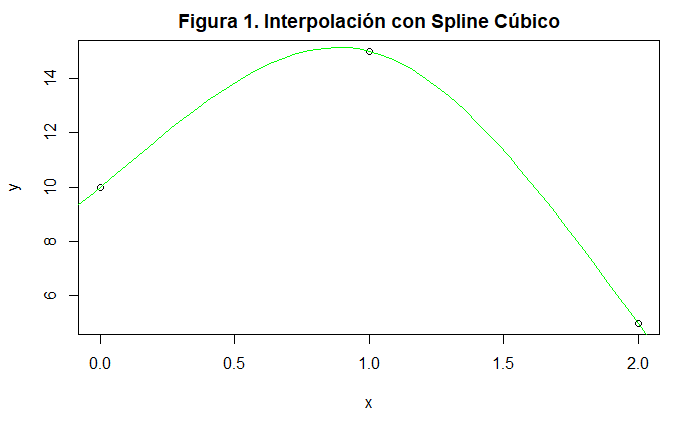

```r
plot(x,y, main="Figura 1. Interpolación con Spline Cúbico")
plot(ffun, xlim=c(-1,3), add=TRUE, col = "green", main="Figura 1. Interpolación Spline Cúbico")
```

#### **Octavo punto:**

8)Considere el comportamiento de gases no ideales se describe a menudo con la ecuación virial de estado. Los siguientes datos para el nitrógeno N2 T(K) 100 200 300 400 450 500 600 B(cm3)/mol -160 -35 -4.2 9.0 16.9 21.3 Donde T es la temperatura [K] y B es el segundo coeﬁciente virial. El comportamiento de gases no ideales se describe a menudo con la ecuaci´on virial de estado
$$\frac{PV}{RT} = 1+\frac{B}{V}+\frac{C}{V^2}+....,$$

1. Donde P es la presión, V el volumen molar del gas, T es la temperatura Kelvin y R es la constante de gas ideal.Los coeﬁcientes $B = B(T)$, $C = C(T)$, son el segundo y tercer coeﬁciente virial, respectivamente. En la práctica se usa la serie truncada para aproximar
   $$\frac{PV}{RT} = 1+\frac{B}{V}$$
2. En la siguiente ﬁgura se muestra como se distribuye la variable B a lo largo de la temperatura
1. Determine un polinomio interpolante para este caso

El polinomio $y = (-4.9375e^-8)x^4+(8.0175e^-5)x^3-(4.6781e^-2)x^2+11.67475x-1061.1$ fue obtenido al utilizar la función “poly_calc” de la librería “PolynomF”. En este caso no se tuvo en cuenta el primer punto ya que se consideró un punto atípico, que haría que no se genere de forma correcta el polinomio.

2. Utilizando el resultado anterior calcule el segundo y tercer coeﬁciente virial a 450K.

Al evaluar el polinomio con $x=450$, el resultado fue de $0.59765625$.

3. Graﬁque los puntos y el polinomio que ajusta

Se graficaron datos reales (figuras de color rojo) y datos interpolados (puntos azules).

```r
require(Matrix)
require(PolynomF)
library(Matrix)
library(PolynomF)
T = c(200,300,400,500,600)
B = c(-35,-4.2,-9,16.9,21.3)
resultado = poly_calc(T,B)
resultado
```

```
-1061.1 + 11.67475*x - 0.04678125*x^2 + 8.0175e-05*x^3 - 4.9375e-08*x^4
```

```r
#B
cat("->en 450",resultado(450),"\n")
```

```
->en 450 0.5976563
```

```r
#C
tablaInterpolada = data.frame(seq(200, 600, by=100),resultado(seq(200, 600, by=100)))
tablaInterpolada
```

| seq.200..600..by...100. | resultado.seq.200..600..by...100.. |
| --- | --- |
| 200 | -35.0 |
| 300 | -4.2 |
| 400 | -9.0 |
| 500 | 16.9 |
| 600 | 21.3 |

```r
tablaDatos = data.frame(T,B)
tablaDatos
```

| T | B |
| --- | --- |
| 200 | -35.0 |
| 300 | -4.2 |
| 400 | -9.0 |
| 500 | 16.9 |
| 600 | 21.3 |

```r
plot(tablaDatos,pch=15, cex=2, col = "red", xlab="X",ylab="Y")
par(new = TRUE)
```

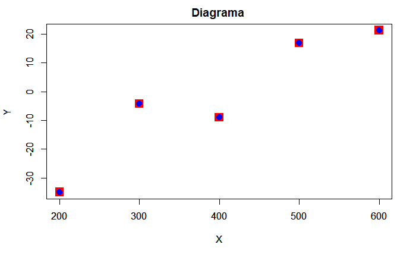

```r
plot(tablaInterpolada, pch=20, cex=2, col = "blue",xlab="X", ylab="Y", main="Diagrama ")
par(new = TRUE)
```

4. Utilice la interpolación de Lagrange y escriba el polinomio interpolante
5. Compare su resultado con la serie truncada (modelo teórico), cuál aproximacion es mejor por qué?